# ProsperLoan Data

## by (Pham Minh Nhat Anh )

# Questions

##### 1)What factors affect a loan’s outcome status?

##### 2)What affects the borrower’s APR or interest rate?

##### 3)Are there differences between loans depending on how large the original loan amount was?

# Main focus

### What is the structure of your dataset?

There are total of 113937 loans entries saved in the dataset and 81 attributes. Each loan contain information on the borrowered's background information and details regarding the loans

### What is/are the main feature(s) of interest in your dataset?

The Loanstatus will be analyzied with many factors such as montyly payment, investors, income, answer the question : who is currently in debt relationsip of borrower APR and LoanStatus, Occupation, credits answer the question: what job cause risky and bad credit

### What features in the dataset do you think will help support your investigation into your feature(s) of interest?

Occpupation , creadit score, LoanStatus will find what is the charateristic of a good/bad customers

```python
df=pd.read_csv("loan.csv")
df.head()
```

|  | ListingKey | ListingNumber | ListingCreationDate | CreditGrade | Term | LoanStatus | ClosedDate | BorrowerAPR | BorrowerRate | LenderYield | ... | LP_ServiceFees | LP_CollectionFees | LP_GrossPrincipalLoss | LP_NetPrincipalLoss | LP_NonPrincipalRecoverypayments | PercentFunded | Recommendations | InvestmentFromFriendsCount | InvestmentFromFriendsAmount | Investors |
| --- | --- | --- | --- | --- | --- | --- | --- | --- | --- | --- | --- | --- | --- | --- | --- | --- | --- | --- | --- | --- | --- |
| 0 | 1021339766868145413AB3B | 193129 | 2007-08-26 19:09:29.263000000 | C | 36 | Completed | 2009-08-14 00:00:00 | 0.16516 | 0.1580 | 0.1380 | ... | -133.18 | 0.0 | 0.0 | 0.0 | 0.0 | 1.0 | 0 | 0 | 0.0 | 258 |
| 1 | 10273602499503308B223C1 | 1209647 | 2014-02-27 08:28:07.900000000 | NaN | 36 | Current | NaN | 0.12016 | 0.0920 | 0.0820 | ... | 0.00 | 0.0 | 0.0 | 0.0 | 0.0 | 1.0 | 0 | 0 | 0.0 | 1 |
| 2 | 0EE9337825851032864889A | 81716 | 2007-01-05 15:00:47.090000000 | HR | 36 | Completed | 2009-12-17 00:00:00 | 0.28269 | 0.2750 | 0.2400 | ... | -24.20 | 0.0 | 0.0 | 0.0 | 0.0 | 1.0 | 0 | 0 | 0.0 | 41 |
| 3 | 0EF5356002482715299901A | 658116 | 2012-10-22 11:02:35.010000000 | NaN | 36 | Current | NaN | 0.12528 | 0.0974 | 0.0874 | ... | -108.01 | 0.0 | 0.0 | 0.0 | 0.0 | 1.0 | 0 | 0 | 0.0 | 158 |
| 4 | 0F023589499656230C5E3E2 | 909464 | 2013-09-14 18:38:39.097000000 | NaN | 36 | Current | NaN | 0.24614 | 0.2085 | 0.1985 | ... | -60.27 | 0.0 | 0.0 | 0.0 | 0.0 | 1.0 | 0 | 0 | 0.0 | 20 |

5 rows × 81 columns

```python
df.info()
```

```
<class 'pandas.core.frame.DataFrame'>
RangeIndex: 113937 entries, 0 to 113936
Data columns (total 81 columns):
ListingKey                             113937 non-null object
ListingNumber                          113937 non-null int64
ListingCreationDate                    113937 non-null object
CreditGrade                            28953 non-null object
Term                                   113937 non-null int64
LoanStatus                             113937 non-null object
ClosedDate                             55089 non-null object
BorrowerAPR                            113912 non-null float64
BorrowerRate                           113937 non-null float64
LenderYield                            113937 non-null float64
EstimatedEffectiveYield                84853 non-null float64
EstimatedLoss                          84853 non-null float64
EstimatedReturn                        84853 non-null float64
ProsperRating (numeric)                84853 non-null float64
ProsperRating (Alpha)                  84853 non-null object
ProsperScore                           84853 non-null float64
ListingCategory (numeric)              113937 non-null int64
BorrowerState                          108422 non-null object
Occupation                             110349 non-null object
EmploymentStatus                       111682 non-null object
EmploymentStatusDuration               106312 non-null float64
IsBorrowerHomeowner                    113937 non-null bool
CurrentlyInGroup                       113937 non-null bool
GroupKey                               13341 non-null object
DateCreditPulled                       113937 non-null object
CreditScoreRangeLower                  113346 non-null float64
CreditScoreRangeUpper                  113346 non-null float64
FirstRecordedCreditLine                113240 non-null object
CurrentCreditLines                     106333 non-null float64
OpenCreditLines                        106333 non-null float64
TotalCreditLinespast7years             113240 non-null float64
OpenRevolvingAccounts                  113937 non-null int64
OpenRevolvingMonthlyPayment            113937 non-null float64
InquiriesLast6Months                   113240 non-null float64
TotalInquiries                         112778 non-null float64
CurrentDelinquencies                   113240 non-null float64
AmountDelinquent                       106315 non-null float64
```

[output cut: 31 more lines]

```
LP_CustomerPayments                    113937 non-null float64
LP_CustomerPrincipalPayments           113937 non-null float64
LP_InterestandFees                     113937 non-null float64
LP_ServiceFees                         113937 non-null float64
LP_CollectionFees                      113937 non-null float64
LP_GrossPrincipalLoss                  113937 non-null float64
LP_NetPrincipalLoss                    113937 non-null float64
LP_NonPrincipalRecoverypayments        113937 non-null float64
PercentFunded                          113937 non-null float64
Recommendations                        113937 non-null int64
InvestmentFromFriendsCount             113937 non-null int64
InvestmentFromFriendsAmount            113937 non-null float64
Investors                              113937 non-null int64
dtypes: bool(3), float64(50), int64(11), object(17)
memory usage: 68.1+ MB
```

## I)Univariate Exploration

> In this section, investigate distributions of individual variables. If you see unusual points or outliers, take a deeper look to clean things up and prepare yourself to look at relationships between variables.

## 1)What factor affect the loan status ?

```python
# count variable
status_count=df1["LoanStatus"].value_counts()
status_count
```

```
Current                   56576
Completed                 38074
Chargedoff                11992
Defaulted                  5018
Past Due (1-15 days)        806
Past Due (31-60 days)       363
Past Due (61-90 days)       313
Past Due (91-120 days)      304
Past Due (16-30 days)       265
FinalPaymentInProgress      205
Past Due (>120 days)         16
Cancelled                     5
Name: LoanStatus, dtype: int64
```

### Loan Status

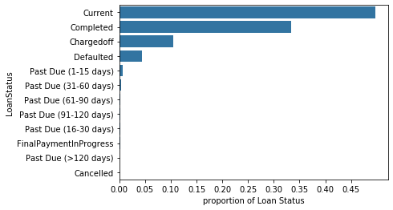

```python
# draw bar chart
base_color=sb.color_palette()[0]
sb.countplot( data=df1,y="LoanStatus",color=base_color,order=status_order)
plt.xticks(tick_pro*n_status,tick_names)
plt.xlabel('proportion of Loan Status')
```

-**Choose 4 significant variables of income to plot which is `Current` , `Completed`,`Chargedoff`,`Defaulted` to plot bivate charts**

Monthly income , monly payment , bank card credit

### Occupation

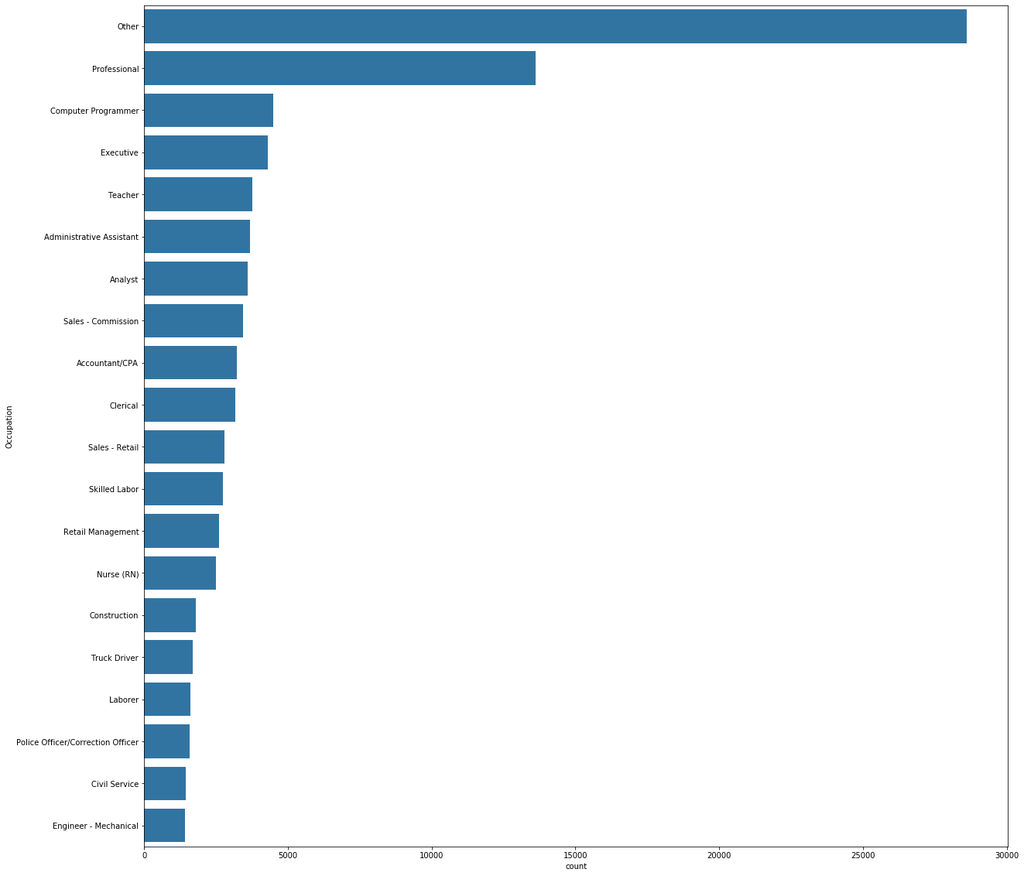

```python
#set value for ticks
Occupation_value=df1["Occupation"].value_counts()
ticks = [Occupation_value.min(),Occupation_value.max(), 3000]
labels = ['{}'.format(val) for val in ticks]
# create order to rank
Occupation_order=df1["Occupation"].value_counts().index
#increase the space for the plot
plt.figure(figsize=(20,20))
# set color
base_color=sb.color_palette()[0]
# plot bar
g=sb.countplot(data=df1, y="Occupation", color=base_color,order=Occupation_order[:20])
```

### Credit Grade

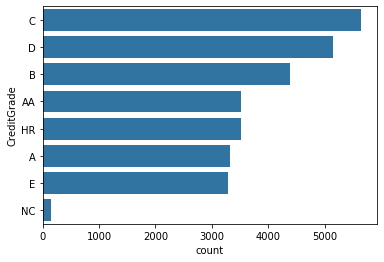

```python
# get order for credit
credit_order=df1["CreditGrade"].value_counts().index
#plot
g=sb.countplot(data=df1, y="CreditGrade", color=base_color,order=credit_order)
```

**AA: high credit quality , A: acceptable safety , B: low safety , D : lowest safety , NC: not competed, there are alot customers have hight risk , need to becareful**

### Discuss the distribution(s) of your variable(s) of interest. Were there any unusual points? Did you need to perform any transformations?

> there are alot of computer programmer borrow money ,

### Of the features you investigated, were there any unusual distributions? Did you perform any operations on the data to tidy, adjust, or change the form of the data? If so, why did you do this?

> alot of risky cutomers with C,D,B credit, ther is alot of NA , value but can not drop because it will be bias

## II)Bivariate Exploration

> In this section, investigate relationships between pairs of variables in your data. Make sure the variables that you cover here have been introduced in some fashion in the previous section (univariate exploration).

#### Factors usually effect Loan include income, employment history , debt you own , apply for loan recently ,collateral , investment , monthly loan payment

### Loan Status with Monthly payment

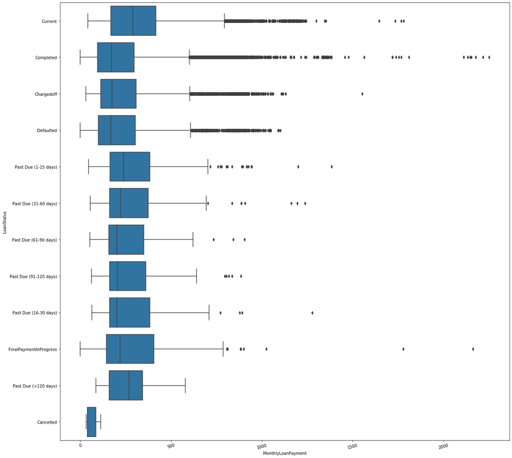

```python
# violin plot
plt.figure(figsize=(20,20))
base_color=sb.color_palette()[0]
sb.boxplot(data=df,x="MonthlyLoanPayment",y="LoanStatus",color=base_color, order=status_order)
plt.xticks(rotation=15)
```

**Most of people in debt and people who past the dueday pay more often than others**

### Investor and loan status

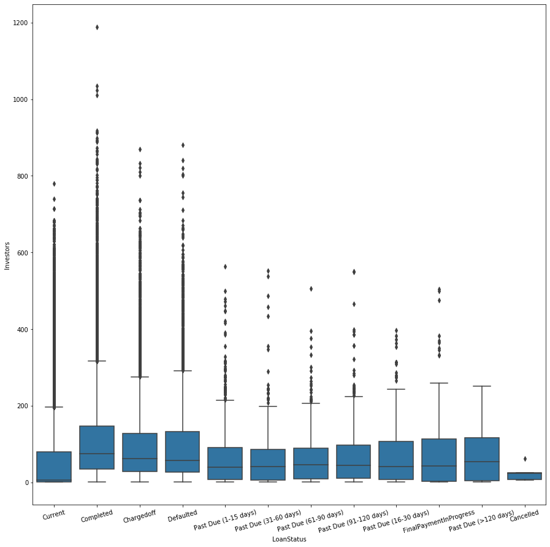

```python
# boxplot
plt.figure(figsize=(15,15))
base_color=sb.color_palette()[0]
sb.boxplot(data=df,x="LoanStatus",y="Investors",color=base_color, order=status_order)
plt.xticks(rotation=15)
```

**Completed loan has the most investor and ouliers , while people who are in debt have the lowest invest, the other variables have realtive same mean of investors**

### Income with Loan Status

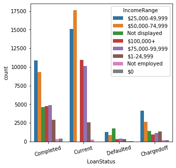

```python
# groupby to see counts of 2 catergorical variable
income_status=df1.groupby(["LoanStatus",'IncomeRange']).size()
# create table
income_status=income_status.reset_index(name="count")
# make pivot table
income_status.pivot(index="LoanStatus",columns="IncomeRange",values="count")


#plot
plt.figure(figsize=(5,5))

income_status_sub = df1.loc[df1['LoanStatus'].isin(['Current','Completed','Chargedoff','Defaulted'])]

ax = sb.countplot(data=income_status_sub, x='LoanStatus', hue='IncomeRange')
# legend top right
ax.legend(loc=1, framealpha=1, title='IncomeRange')
plt.xticks(rotation=15)
```

**People who have high income range would around '25k- 49k' dollar rank the 1st in complete and charged off the debt, most of current loan is owned by the middle income '50k - 79k' dollar , and default group most of them doesn't show income, middle income people borrow alot**

## 2)Difference between Loans depending on how large the OriginalLoan amount?

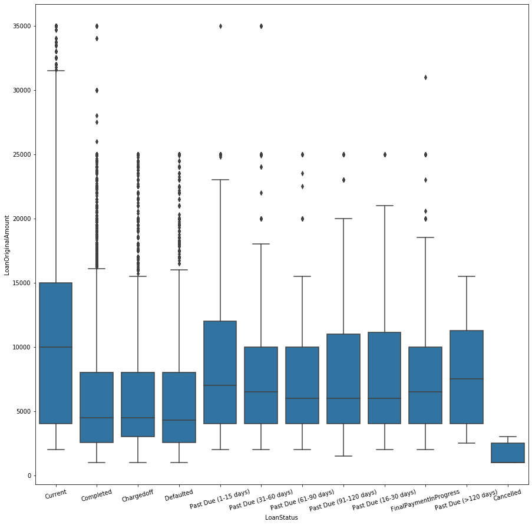

```python
# boxplot
plt.figure(figsize=(15,15))
base_color=sb.color_palette()[0]
sb.boxplot(data=df,x="LoanStatus",y="LoanOriginalAmount",color=base_color, order=status_order)
plt.xticks(rotation=15)
```

**people how are curently in debt have really huge amount of oringial Loan amount**

## 3)What factors affect APR

> APR la interestrate + origination fee adn docuemtnation fee, provide yearly rate

### BorrowerAPR and Loan Status

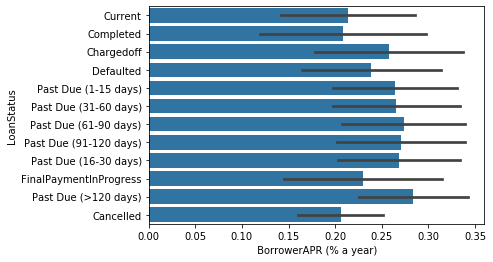

```python
# plotting
base_color = sb.color_palette()[0]
sb.barplot(data = df1, x = 'BorrowerAPR', y = 'LoanStatus',
               color = base_color, order =status_order, ci = 'sd')
plt.xlabel(' BorrowerAPR (% a year)')
```

**Charged off customers adn pastdue customers have the highest BorrowerAPR rate,most high borrow rate make are past due , charged off or default**

### Borrower APR vs Occupation

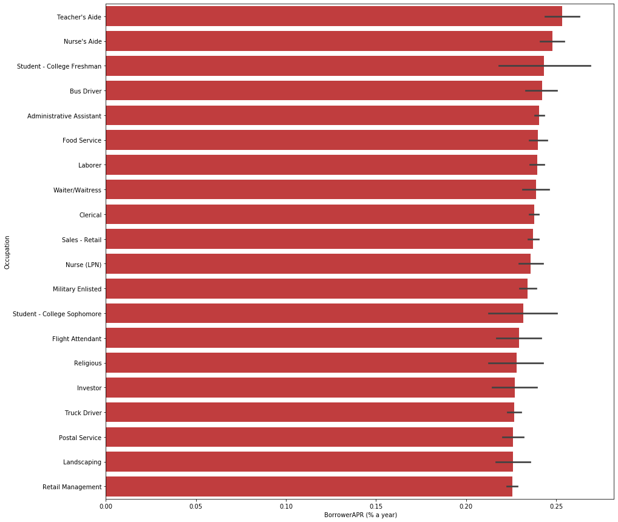

```python
occupation=df.groupby("Occupation")["BorrowerAPR"].mean().reset_index(name="Mean")
occupation.sort_values(by="Mean",ascending=False,inplace=True)
# plotting and re check
plt.figure(figsize=(15,15))
base_color= sb.color_palette()[3]
sb.barplot(data = df1, x = 'BorrowerAPR', y = 'Occupation',order=occupation.Occupation[:20] ,color=base_color)
plt.xlabel(' BorrowerAPR (% a year)')
```

**Teacher's Aide, Nurse's Aide, Student - College Freshman are 3 types of people have the biggest APR borrow rate , with high fee**

### Borrow rate and credit

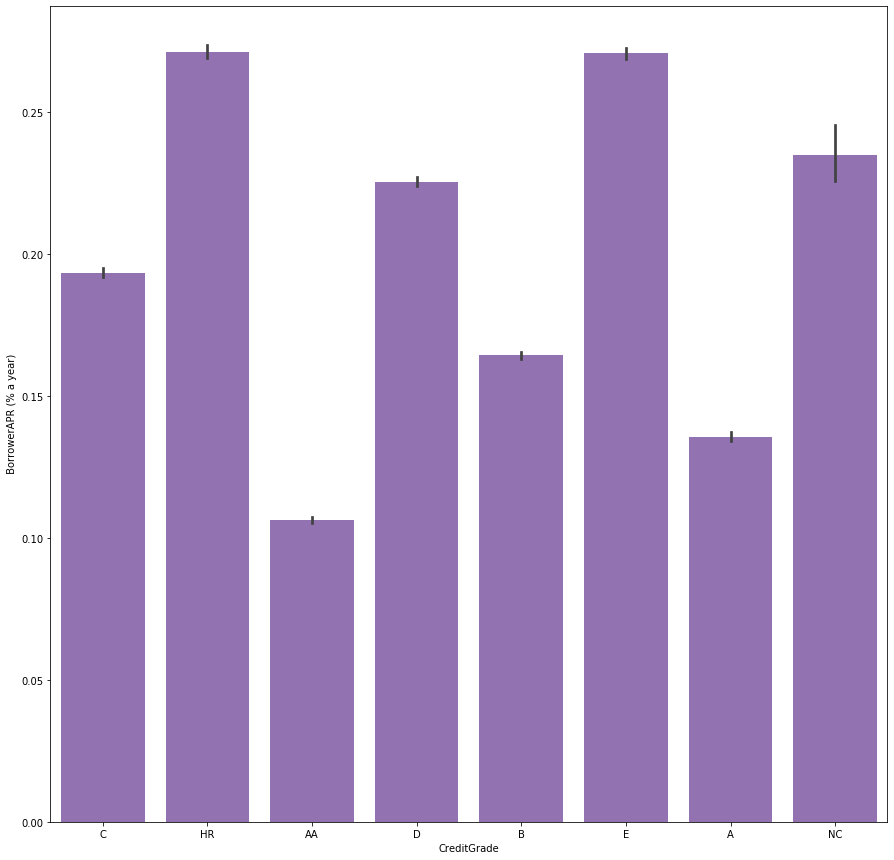

```python
# plotting and re check
plt.figure(figsize=(15,15))
base_color= sb.color_palette()[4]
sb.barplot(data = df1, y = 'BorrowerAPR',  x= 'CreditGrade', color=base_color)
plt.ylabel(' BorrowerAPR (% a year)')
```

**most of customers have high borrow are clasified as HR credit( has high percentage of loss)**

**Most of customers here has really bad credit score**

### Occupation and Credit

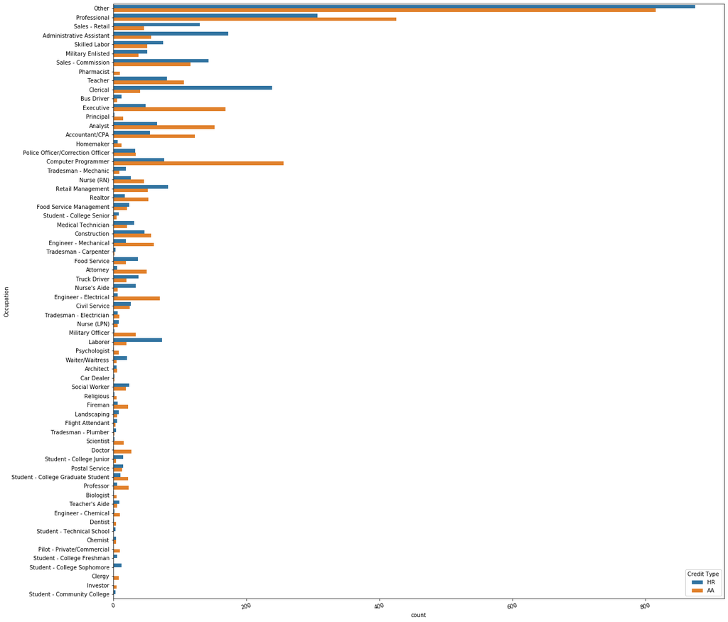

```python
#group by 2 varibles to cacualte frequency
oc=df1.groupby(["Occupation",'CreditGrade']).size()
oc=oc.reset_index(name="count")
oc
# plotting and set size
plt.figure(figsize=(20,20))
oc = df1.loc[df1['CreditGrade'].isin(['HR', 'AA'])]
ax = sb.countplot(data=oc, y='Occupation', hue='CreditGrade')
ax.legend(loc=4, framealpha=1, title='Credit Type') # lower right, no transparency
plt.xticks(rotation=15);
```

**Jobs which are related to others , Profesional, clerical and Administration has the most risks because of bad credit. Good credit include people from others , professional,computer programmer jobs**

### Talk about some of the relationships you observed in this part of the investigation. How did the feature(s) of interest vary with other features in the dataset?

> high borrow rate are easy to past due, default and chardged off

### Did you observe any interesting relationships between the other features (not the main feature(s) of interest)?

> students , nurse, teachers have higher APR borrow fee even they are not really rich, job related to profession or business are really risky

# III) Multivariate Exploration

> Create plots of three or more variables to investigate your data even further. Make sure that your investigations are justified, and follow from your work in the previous sections.

### Check BorrowerAPR relationship with the rest of the variables

To get a correlation we need to convert our categorical features to numerical ones.

Now we can get the correlation between the 'BorrowerAPR' and all the other features.

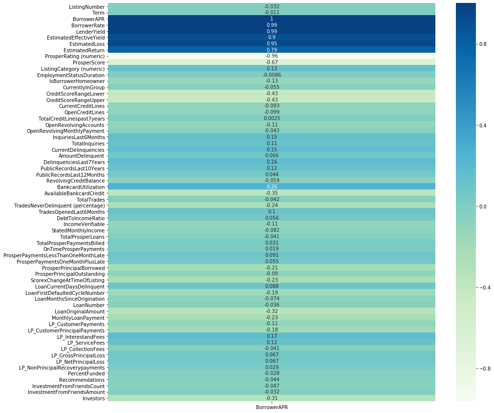

```python
heatmap=df1[df1.columns[1:]].corr()['BorrowerAPR'][:]

f, ax = plt.subplots(figsize=(15, 15))
ax=sb.heatmap(heatmap.to_frame(),annot=True, annot_kws={'size':10},cmap="GnBu")
plt.show()
```

### Checking Loan Status with the rest of the variables

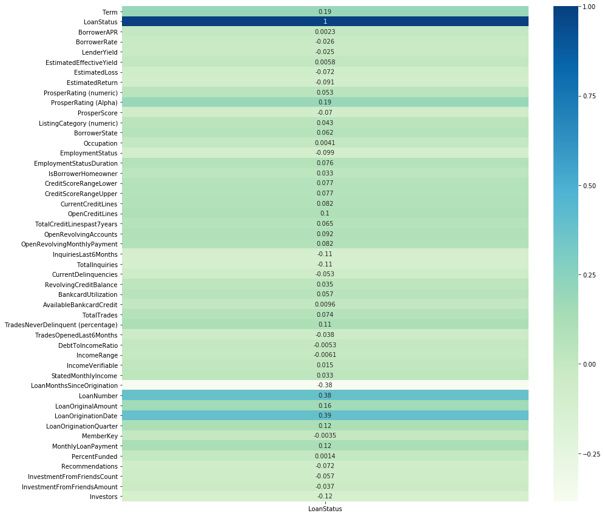

```python
heatmap=df1[df1.columns[1:]].corr()['LoanStatus'][:]

f, ax = plt.subplots(figsize=(15, 15))
ax=sb.heatmap(heatmap.to_frame(),annot=True, annot_kws={'size':10},cmap="GnBu")
plt.show()
```

### Were there any interesting or surprising interactions between features?

> correaltion of loan status can not just find by corr

```python
!jupyter nbconvert loan.ipynb --to slides --post
```

> At the end of your report, make sure that you export the notebook as an html file from the `File > Download as... > HTML` menu. Make sure you keep track of where the exported file goes, so you can put it in the same folder as this notebook for project submission. Also, make sure you remove all of the quote-formatted guide notes like this one before you finish your report!